# Test-Driven Development

Антон Бевзюк  
Июль 2014

# О чем будем говорить?

- Мифы о TDD
- TDD: что это такое и зачем?
- RED/GREEN/REFACTOR
- Демо
- Полезные советы
- Паттерны TDD

На примере C# / MS Visual Studio

# Что такое TDD?

# Мифы о TDD

- Unit testing = TDD
- TDD - практика тестирования
- TDD удваивает объем работы
- Главная цель - 100% покрытие кода тестами
- Все, что требуется - юнит тесты

# Test-Driven Development

- Тесты **до** кода
- Методология **разработки**
- Практика **дизайна**

# Что это даёт?

- Актуальное описание намерений, дизайна и использования системы
- Легкое обнаружение слабых мест в дизайне
- Автоматическое регрессионное тестирование
- Безопасный рефакторинг
- Быстрое обнаружение дефектов

[figure not shown]

# Отладка

> Отладка - это трата времени

Роберт Мартин

# RED / GREEN / REFACTOR

=> Подумай, напиши тест

Скомпилируй

Исправь ошибки

Запусти все тесты и убедись, что они прошли

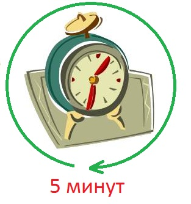

Запусти все тесты и убедись, что они упали

Рефакторинг

Запусти все тесты и убедись, что они прошли

Напиши код

# Демонстрация

# Как начать писать тест?

- Сможешь написать реализацию
- Знаешь, каким будет следующий шаг

[figure not shown]

# Что нужно тестировать?

## Нужно

- Все, что может поломаться

## Не нужно

- set; get
- GUI
- private

[figure not shown]

# Вещи, которые нужно делать всегда

- Сначала тест, потом код
- Список todo
- Новый код только, если есть красный тест
- Запускать все тесты
- Поддерживать качество кода тестов
- Рефакторинг

[figure not shown]

# Вещи, которые делать нельзя никогда

- Несколько красных тестов
- Новый тест до рефакторинга
- Check-in кода с падающими тестами

[figure not shown]

# Хороший unit test

- Сфокусированый (1 assert)
- Быстрый
- Автоматический (легкий запуск)
- Независимый от
- Других тестов
- Окружения
- Порядка запуска
- Такого же качества как и код приложения

[figure not shown]

# Плохие тесты

- Длинная инициализация
- Порочный дизайн
- Слишком большие классы
- Медленные тесты
- > 10 минут для запуска тестов
- Хрупкие тесты
- Высокая вязкость

[figure not shown]

# TDD patterns

- AAA: Arrange Act Assert
- Isolated test
- Test list
- Test First
- Assert First
- Test Data
- Evident Data

# Green Test Patterns

- Fake it
- Obvious Implementation
- Triangulation

# Red Test Patters

- One Step Test
- Starter Test
- Explanation Test
- Learning Test
- Another Test
- Regression Test

# 7 стадий юнит-тестера

1. "У меня нет на это времени".
2. Начинает писать юнит тесты и писать в блоге,  
   как это здорово, и что каждый должен следовать TDD.
3. Тестирует всё подряд - private, get, set. Доводит покрытие до 100%.  
   Злоупотребляет атрибутом `InternalsVisibleTo`.
4. Пишет хрупкие тесты, по сути являющиеся интеграционными.
5. Открывает для себя средства, облегчающие тестирование.
6. Подменяет абсолютно всё, что можно подменить.
7. Начинает писать эффективные юнит тесты.

# Контрольные вопросы

1. Что такое TDD, его назначение
2. Мифы о TDD
3. Цикл разработки по TDD (в виде рисунка и с максимумом деталей)
4. Атрибуты хорошего unit-теста (включая AAA)

# Спасибо!

Вопросы?

[figure not shown]